# TP 13/02

Vincent LE MEUR

2024-02-14

# TP R : CR, PLS, Ridge et Lasso

## Compte rendu

### Expliquer/prédire

```
## Regression linéaire :
```

```
##
## Call:
## lm(formula = PRIX ~ ., data = d)
##
## Residuals:
##     Min      1Q  Median      3Q     Max
## -8289.8 -1720.6  -166.6  2913.3  5420.0
##
## Coefficients:
##              Estimate Std. Error t value Pr(>|t|)
## (Intercept) -8239.363  42718.423  -0.193    0.851
## CYL            -3.505      5.551  -0.631    0.541
## PUIS          282.169    174.883   1.613    0.135
## LON           -15.038    129.747  -0.116    0.910
## LAR           208.694    412.048   0.506    0.623
## POIDS          12.575     24.622   0.511    0.620
## VITESSE      -111.114    222.257  -0.500    0.627
##
## Residual standard error: 4406 on 11 degrees of freedom
## Multiple R-squared:  0.7091, Adjusted R-squared:  0.5504
## F-statistic: 4.469 on 6 and 11 DF,  p-value: 0.0156
```

On à un R² pas trop mal et un test global de Fisher nous indiquant que le modèle explique le PRIX de manière significative (p = 0.0156) mieux que le modèle null. Cependant aucune variable n’est significative due à la multicolinéarité

```
## ACP :
```

```
##        eigenvalue percentage of variance cumulative percentage of variance
## comp 1 4.42085806             73.6809677                          73.68097
## comp 2 0.85606229             14.2677048                          87.94867
## comp 3 0.37306608              6.2177680                          94.16644
## comp 4 0.21392209              3.5653682                          97.73181
## comp 5 0.09280121              1.5466869                          99.27850
## comp 6 0.04329027              0.7215045                         100.00000
```

VIF pour voir la multicolinéarité (grand)

vif

|  | x |
| --- | --- |
| CYL | 3.772013 |
| PUIS | 11.118820 |
| LON | 7.204195 |
| LAR | 4.197605 |
| POIDS | 9.957283 |
| VITESSE | 6.375112 |

## Solutions à la multicolinéarité: stepAIC, PCR, PLS, Ridge et Lasso

### stepAIC

```
##
## Call:
## lm(formula = PRIX ~ PUIS + POIDS, data = d)
##
## Residuals:
##     Min      1Q  Median      3Q     Max
## -7148.2 -1874.6   296.3  2012.7  5263.7
##
## Coefficients:
##             Estimate Std. Error t value Pr(>|t|)
## (Intercept)  1775.60    8030.95   0.221   0.8280
## PUIS          172.97      72.42   2.388   0.0305 *
## POIDS          16.45      10.77   1.527   0.1476
## ---
## Signif. codes:  0 '***' 0.001 '**' 0.01 '*' 0.05 '.' 0.1 ' ' 1
##
## Residual standard error: 3916 on 15 degrees of freedom
## Multiple R-squared:  0.6866, Adjusted R-squared:  0.6448
## F-statistic: 16.43 on 2 and 15 DF,  p-value: 0.0001661
```

Ce sont les variables PUIS et POIDS qui sont sélectionnées par le stepAIC (stratégie backward), avec seul la variable PUIS significative. C’est un modèle assez propre car on peut vérifier que les conditions d’application sont vérifiées (normalité, homoscédasticité et indépendance des résidus)

#### Erreur de prédiction par validation croisée

$$MSEP : \frac{1}{n} \sum_{i=1}^{n} (y_i -
\hat{y}_i^{(-i)})^{2}$$

$$RMSEP : \sqrt{MSEP}$$

```
## [1] "RMSEP:"
```

```
## [1] "aic:"
```

```
## [1] 4139.89
```

```
## [1] "m0:"
```

```
## [1] 6380.208
```

## Régression sur les composantes principales (PCR)

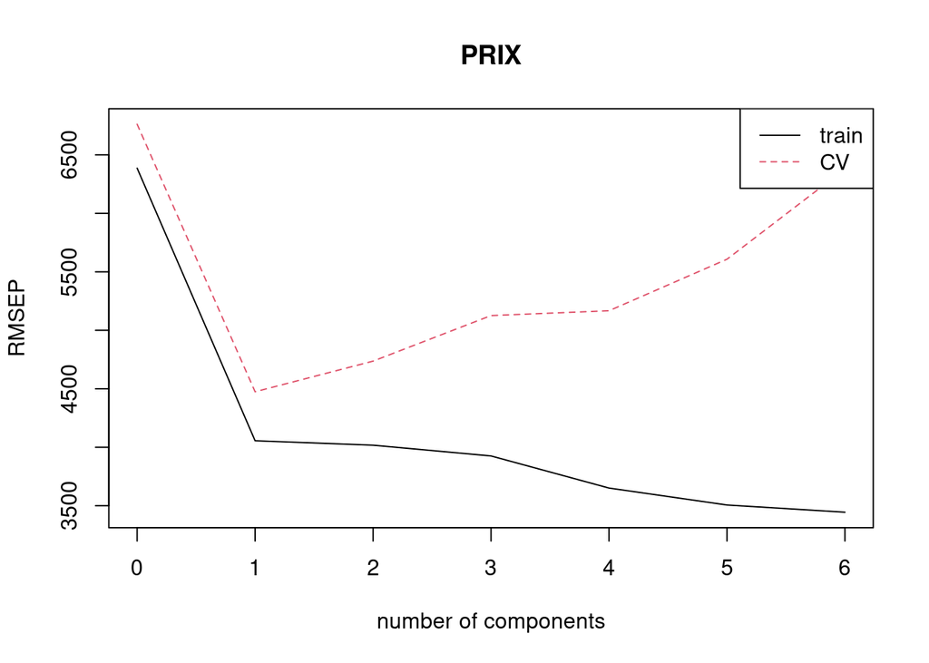

```
## Data:    X dimension: 18 6
##  Y dimension: 18 1
## Fit method: svdpc
## Number of components considered: 6
##
## VALIDATION: RMSEP
## Cross-validated using 18 leave-one-out segments.
##        (Intercept)  1 comps  2 comps  3 comps  4 comps  5 comps  6 comps
## CV            6762     4475     4737     5126     5167     5608     6380
## adjCV         6762     4461     4716     5097     5123     5547     6295
##
## TRAINING: % variance explained
##       1 comps  2 comps  3 comps  4 comps  5 comps  6 comps
## X       73.68    87.95    94.17    97.73    99.28   100.00
## PRIX    59.67    60.42    62.22    67.32    69.86    70.91
```

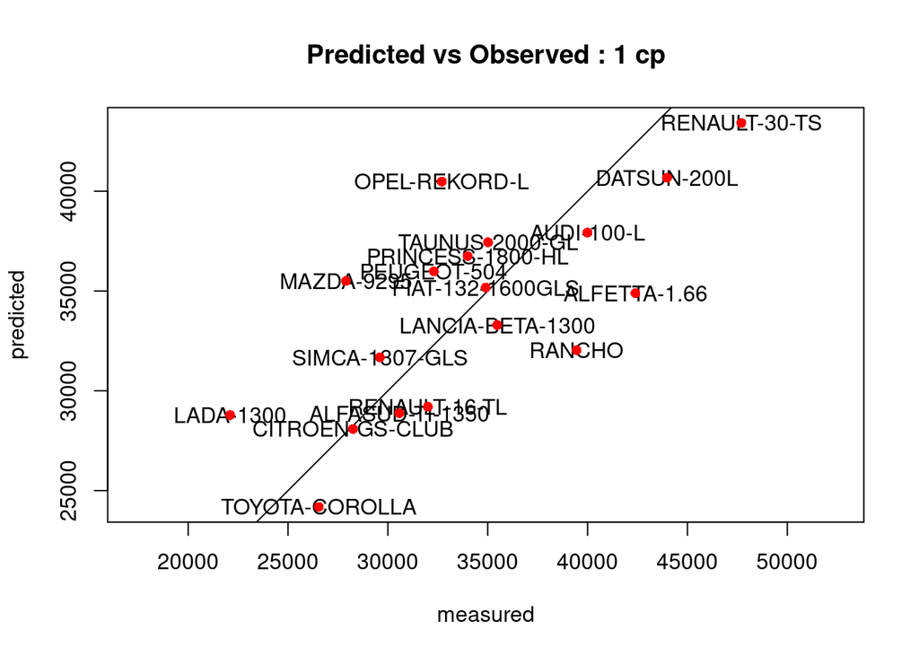

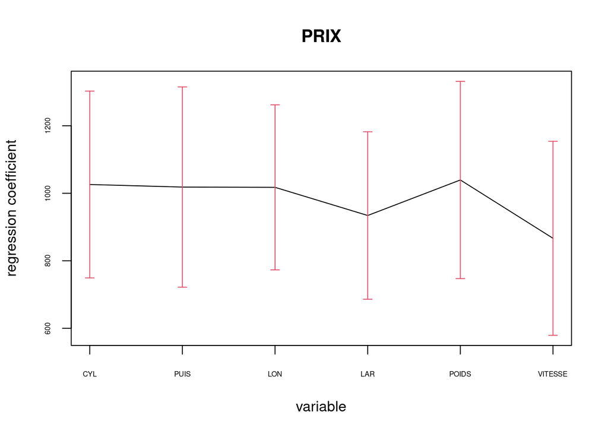

On obtient l’intercept avec:

```
## , , 1 comps
##
##                    PRIX
## (Intercept) -43286.4592
## CYL           1025.9460
## PUIS          1018.3610
## LON           1017.5534
## LAR            934.1672
## POIDS         1039.4083
## VITESSE        866.6185
```

Ces coefficents sont cependant ceux obtenus avec les variables réduites (mais pas centrées

```
##        CYL       PUIS        LON        LAR      POIDS    VITESSE
##   2.743686  49.977766  46.027817 175.803886   7.589259  71.383131
```

Le modèle de régression obtenu est donc :
$$PRIX = -43286.46 +2.75CYL +49.98PUIS + 46.03LON
+175.80LAR + 7.59POIDS + 71.38VITESSE + erreu r$$

Les coefficients sont positifs : Plus la voiture a des caractéristiques élévées, plus elle est chèr

#### Prédictions

```
##    CYL PUIS LON LAR POIDS VITESSE
## 1 1600  100 450 180  1400     160
```

```
##      PRIX
## 1 40504.7
```

### Prédiction PLS

```
## Data:    X dimension: 18 6
##  Y dimension: 18 1
## Fit method: kernelpls
## Number of components considered: 6
##
## VALIDATION: RMSEP
## Cross-validated using 18 leave-one-out segments.
##        (Intercept)  1 comps  2 comps  3 comps  4 comps  5 comps  6 comps
## CV            6762     4515     5495     5601     5987     6270     6380
## adjCV         6762     4502     5440     5545     5919     6189     6295
##
## TRAINING: % variance explained
##       1 comps  2 comps  3 comps  4 comps  5 comps  6 comps
## X       73.62    82.66    91.92    96.59    99.07   100.00
## PRIX    60.84    67.08    69.45    70.36    70.81    70.91
```

#### RIDGE regression

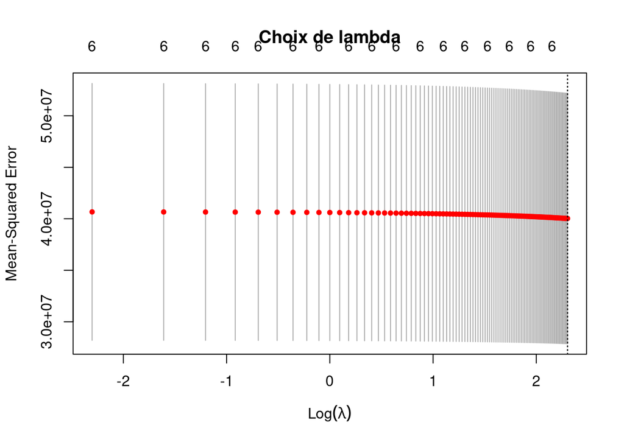

On observe que la décroissance de l’erreur de prédiction n’est pas assez prononcée, du coup, on élargi l’intervalle de lambda ! Posons lambda = seq(0,100000, 10)

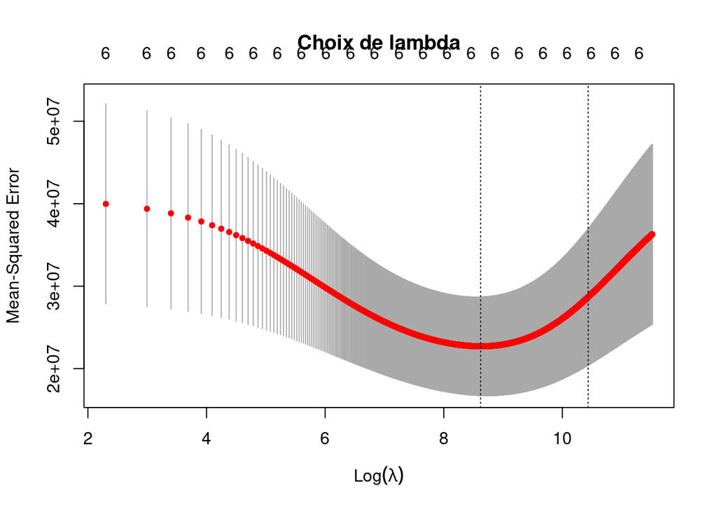

On trouve la valeur optimale : lambda_optimal=5550 pour laquelle on obtient une MSEP égale à 2.271493^{7} ce qui correspond à un RMSEP = sqrt(MSEP) = 4766.0183018

```
## 7 x 1 sparse Matrix of class "dgCMatrix"
##                        s0
## (Intercept) -17937.407121
## CYL              1.324353
## PUIS            72.631483
## LON             29.839976
## LAR             79.819401
## POIDS            8.812178
## VITESSE         50.821733
```

Ridge fait moins bien que PLS et PCR

### LASSO

On fait la même chose que pour Ridge en prenant $\alpha$=1

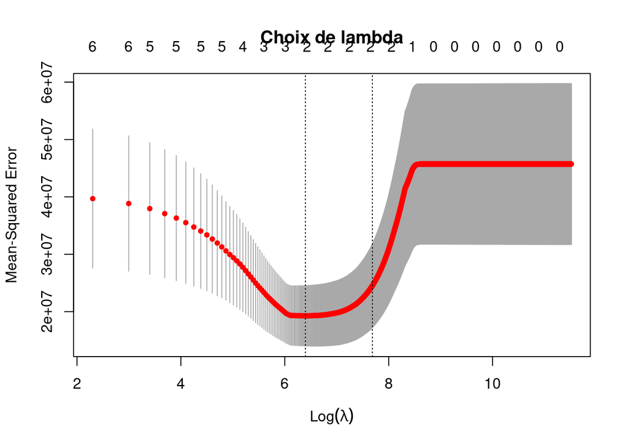

```
## [1] 600
```

```
## 7 x 1 sparse Matrix of class "dgCMatrix"
##                     s0
## (Intercept) 5985.12074
## CYL            .
## PUIS         155.86314
## LON            .
## LAR            .
## POIDS         13.89069
## VITESSE        .
```

On trouve la valeur optimale : lambda_optimal=600 pour laquelle on obtient une MSEP égale à 1.9273445^{7} ce qui correspond à un RMSEP = sqrt(MSEP) = 4390.1531695

Le RMSEP de Lasso est le meilleur parli les modèle PCR,PLS et Ridge. Il selectionne les mêmes variables que stepAIC mais ne le bat pas en termes de prédiction